# Сборный Проект — 2. HR-аналитика

## 3. Исследовательский анализ данных

Проведем статистический анализ данных.

```python
display(train_job_sr.describe())
display(train_job_sr.describe(exclude = 'number'))
```

|  | id | employment_years | supervisor_evaluation | salary | job_satisfaction_rate |
| --- | --- | --- | --- | --- | --- |
| count | 4000.000000 | 4000.000000 | 4000.000000 | 4000.000000 | 4000.000000 |
| mean | 544957.621000 | 3.718500 | 3.476500 | 33926.700000 | 0.533995 |
| std | 257883.104622 | 2.542513 | 1.008812 | 14900.703838 | 0.225327 |
| min | 100954.000000 | 1.000000 | 1.000000 | 12000.000000 | 0.030000 |
| 25% | 322836.750000 | 2.000000 | 3.000000 | 22800.000000 | 0.360000 |
| 50% | 534082.500000 | 3.000000 | 4.000000 | 30000.000000 | 0.560000 |
| 75% | 771446.000000 | 6.000000 | 4.000000 | 43200.000000 | 0.710000 |
| max | 999521.000000 | 10.000000 | 5.000000 | 98400.000000 | 1.000000 |

|  | dept | level | workload | last_year_promo | last_year_violations |
| --- | --- | --- | --- | --- | --- |
| count | 3994 | 3996 | 4000 | 4000 | 4000 |
| unique | 5 | 3 | 3 | 2 | 2 |
| top | sales | junior | medium | no | no |
| freq | 1512 | 1894 | 2066 | 3880 | 3441 |

В целом все хорошо.  
Далее строим диаграммы распределения.

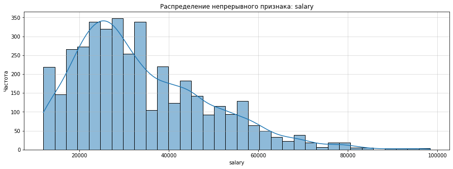

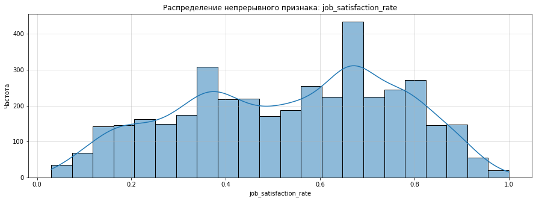

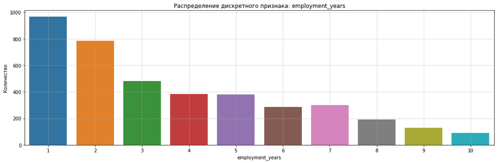

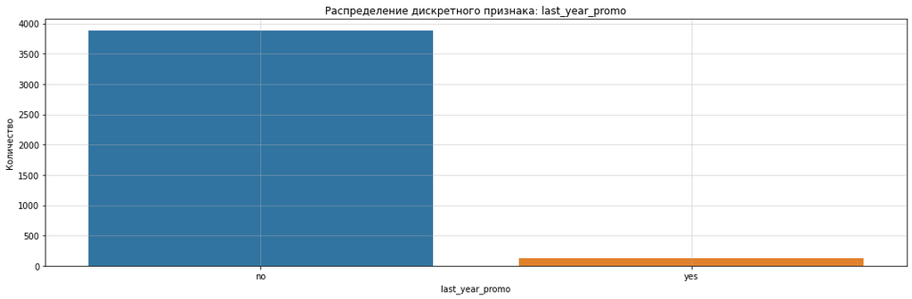

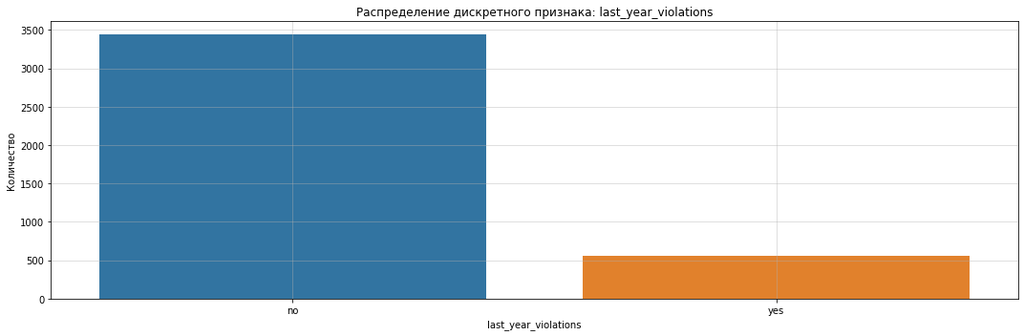

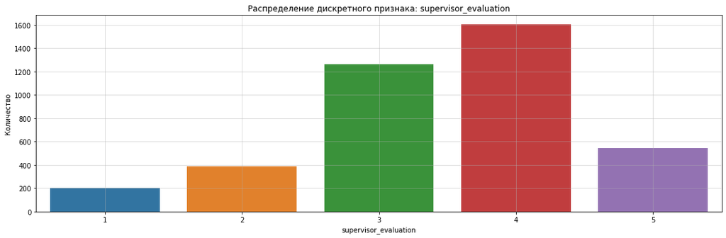

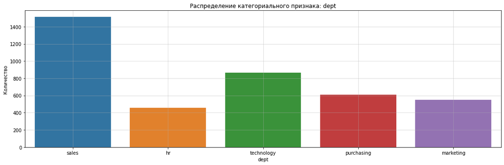

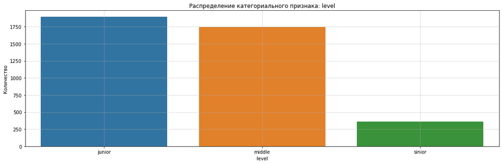

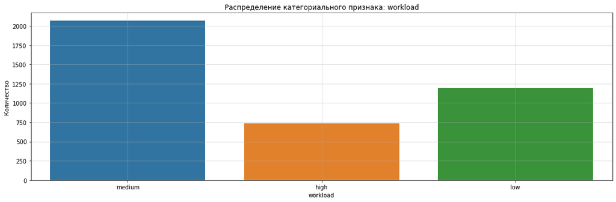

```python
cat_cols = ['dept', 'level', 'workload']
discrete_cols = ['employment_years', 'last_year_promo', 'last_year_violations', 'supervisor_evaluation']
continuous_cols = ['salary', 'job_satisfaction_rate']

for col in continuous_cols:
    plt.figure(figsize=(15, 5))
    sns.histplot(
        data=train_job_sr[col],
        kde=True,
        bins='auto'
    )
    plt.grid(True, linestyle='-', alpha=0.5)
    plt.title(f"Распределение непрерывного признака: {col}")
    plt.xlabel(col)
    plt.ylabel('Частота')
    plt.show()

for col in discrete_cols:
    plt.figure(figsize=(15, 5))
    sns.countplot(
        x=train_job_sr[col]
    )
    plt.grid(True, linestyle='-', alpha=0.5)
    plt.title(f"Распределение дискретного признака: {col}")
    plt.xlabel(col)
    plt.ylabel('Количество')
    plt.tight_layout()
    plt.show()

for col in cat_cols:
    plt.figure(figsize=(15, 5))
    sns.countplot(
        x=train_job_sr[col]
    )
    plt.grid(True, linestyle='-', alpha=0.5)
    plt.title(f"Распределение категориального признака: {col}")
    plt.xlabel(col)
    plt.ylabel('Количество')
    plt.tight_layout()
    plt.show()
```

Выводы:

- Средняя зар. плата 34000, по мере увеличения, снижается частота.
- Средний уровень удовлетворенности примерно 0.53, распределение до 0.5 и после примерно равномерное.
- Большинство сотрудников работают до 3 лет.
- Повышения бывают крайне редко.
- Нарушения сотрудников встречаются, но не часто.
- Большинство сотрудников имеют оценку от руководства 3 и 4 балла.
- Большинство сотрудников работает в отделе продаж.
- Уровень сотрудников в большинстве случаев junior и middle.
- Большинство сотрудников загруженны средне.

Дополнительно посмотрим на сотрудников с индексом удовлетворенности выше **0.75** и меньше **0.25**.

```python
good_job = train_job_sr[train_job_sr['job_satisfaction_rate'] > 0.75]
print(good_job.shape)

bad_job = train_job_sr[train_job_sr['job_satisfaction_rate'] < 0.25]
print(bad_job.shape)
```

```
(780, 10)
(532, 10)
```

- 20% удовлетворенны своей работой.
- 13% крайне недовольны своей работой.

Проведем корреляционный анализ данных.

```python
# построим корреляционную матрицу phik
train_job_sr_corr = train_job_sr.drop(columns = 'id')

interval_cols = ['salary', 'job_satisfaction_rate']
```

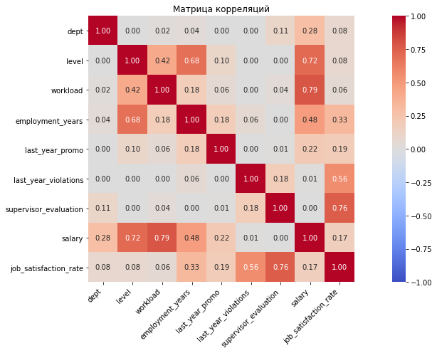

```python
corr_matrix = train_job_sr_corr.phik_matrix(interval_cols = interval_cols)

plt.figure(figsize = (15, 7))
sns.heatmap(
    data = corr_matrix,
    annot = True,
    fmt = '0.2f',
    vmin = -1,
    vmax = 1,
    cmap = 'coolwarm',
    center = 0,
    square = True
)

plt.title('Матрица корреляций')
plt.xticks(rotation = 45, ha = 'right')
plt.tight_layout()
```

Наибольшая корреляция у индекса удовлетворенности сотрудника:

- Оценка качества работы, которую дал руководитель.
- Нарушения сотрудником трудового договора.
- Колличество проработанных лет.